# STATS503_HW4_Shenyi Tang

#### Quesiton 1

**ISLP chapter 4, conceptual exercise #2**

**It was stated in the text that classifying an observation to the class for which (4.17) is largest is equivalent to classifying an observation to the class for which (4.18) is largest. Prove that this is the case. In other words, under the assumption that the observations in the $k$th class are drawn from a $N(u_k,\sigma^2)$ distribution, the Bayes classifier assigns an observation to the class for which the discriminant function is maximized.**

That is to say， maximizing $$ \begin{equation} p_k(x)=\cfrac{\pi_k\frac{1}{\sqrt{2\pi}\sigma}\text{exp}(-\frac{1}{2\sigma^2}(x-\mu_k)^2)}{\sum_{l=1}^{K}{\pi_l\frac{1}{\sqrt{2\pi}\sigma}\text{exp}(-\frac{1}{2\sigma^2}(x-\mu_l)^2)}} \end{equation} $$ is equivalent to maximizing $$ \begin{equation} \delta_k(x)=x\cdot\cfrac{\mu_k}{\sigma^2}-\cfrac{\mu_k^2}{2\sigma^2}+\text{log}(\pi_k) \end{equation} $$ For each $p_k(x)$, there are only differences in numerator, that is to say, we have to find the largest numerator $\pi_k\frac{1}{\sqrt{2\pi}\sigma}\text{exp}(-\frac{1}{2\sigma^2}(x-\mu_k)^2)$ among all the $k$.

To simplify the process, we can take $\text{log}$ to the numerator of $p_k(x)$, we get $$-\cfrac{x^2}{2\sigma^2}+x\cdot\cfrac{\mu_k}{\sigma^2}-\cfrac{\mu_k^2}{2\sigma^2}+\text{log}(\cfrac{1}{\sqrt{2\pi}\sigma})+\text{log}{\pi_k}$$.

As we only care about $k$-related items, we finally get $x\cdot\cfrac{\mu_k}{\sigma^2}-\cfrac{\mu_k^2}{2\sigma^2}+\text{log}(\pi_k)$, which is $\delta_k$

#### Quesiton 2

**ISLP chapter 4, conceptual exercise #3**

**This problem relates to the QDA model, in which the observations within each class are drawn from a normal distribution with a class-specific mean vector and a class specific covariance matrix. We consider the simple case where $p = 1$; i.e. there is only one feature. Suppose that we have $K$ classes, and that if an observation belongs to the $k$th class then X comes from a one-dimensional normal distribution, $X\sim N(µ_k , \sigma^2_k)$. Recall that the density function for the one-dimensional normal distribution is given in (4.16). Prove that in this case, the Bayes classifier is not linear. Argue that it is in fact quadratic.**

For the cases that variances are different in different classes, we have $$ \begin{equation} p_k(x)=\cfrac{\pi_k\frac{1}{\sqrt{2\pi}\sigma_k}\text{exp}(-\frac{1}{2\sigma^2_k}(x-\mu_k)^2)}{\sum_{l=1}^{K}{\pi_l\frac{1}{\sqrt{2\pi}\sigma_l}\text{exp}(-\frac{1}{2\sigma_l^2}(x-\mu_l)^2)}} \end{equation} $$ Similarly, the denominators are equal for each $p_k(x)$ and we need to find the largest numerator.

Taking $\text{log}$ to the numerator of $p_k(x)$ and cancel the items that are not related with $k$, we can have $$ -\cfrac{x^2}{2\sigma^2_k}+x\cdot\cfrac{\mu_k}{\sigma^2_k}-\cfrac{\mu_k^2}{2\sigma^2_k}+\text{log}(\cfrac{1}{\sqrt{2\pi}\sigma_k})+\text{log}{\pi_k} $$ which is quadratic

#### Question 3

**ISLP chapter 4, conceptual exercise #5, parts a, b, and d**

**We now examine the differences between LDA and QDA**

**(a) If the Bayes decision boundary is linear, do we expect LDA or QDA to perform better on the training set? On the test set?**

- QDA performs better on the training set
  - As QDA is more flexible and results in overfitting and lower training error.
- LDA performs better on the test set
  - As LDA is linear which matches the true decision boundry.

**(b) If the Bayes decision boundary is non-linear, do we expect LDA or QDA to perform better on the training set? On the test set?**

- QDA performs better both on the training set and test set
  - QDA is more flexible, leading to lower training error.
  - QDA aligns better with the true non-linear decision boundary.

**(d) True or False: Even if the Bayes decision boundary for a given problem is linear, we will probably achieve a superior test error rate using QDA rather than LDA because QDA is flexible enough to model a linear decision boundary. Justify your answer.**

- False
  - QDA is more flexible and results in overfitting which takes noises into account and reduces it accuracy in the testing set.

#### Question 4

**ISLP chapter 4, conceptual exercise #7**

**Suppose that we wish to predict whether a given stock will issue a dividend this year (“Yes” or “No”) based on $X$, last year’s percent profit. We examine a large number of companies and discover that the mean value of X for companies that issued a dividend was $\bar{X} = 10$, while the mean for those that didn’t was$\bar{X} = 0$. In addition, the variance of $X$ for these two sets of companies was $\hat{\sigma}^2 = 36$. Finally, $80\%$ of companies issued dividends. Assuming that $X$ follows a normal distribution, predict the probability that a company will issue a dividend this year given that its percentage profit was $X = 4$ last year.**

As provided, $\pi_{yes}=0.8$. We can use LDA to make the classification due to 2 sets of companies have same variance.

For $k=yes,\ X=4$, $$ \begin{align*} \text{Pr}(k=\text{Yes}|X=4) &= \cfrac{\pi_{yes}\frac{1}{\sqrt{2\pi}\sigma}\text{exp}(-\frac{1}{2\sigma^2}(x-\mu_{yes})^2)}{\pi_{yes}\frac{1}{\sqrt{2\pi}\sigma}\text{exp}(-\frac{1}{2\sigma^2}(x-\mu_{yes})^2)+\pi_{no}\frac{1}{\sqrt{2\pi}\sigma}\text{exp}(-\frac{1}{2\sigma^2}(x-\mu_{no})^2)} \\ &= \cfrac{0.8\times\text{exp}(-\frac{1}{2\times36}(4-10)^2)}{0.8\times\text{exp}(-\frac{1}{2\times36}(4-10)^2)+0.2\times\text{exp}(-\frac{1}{2\times36}(4-0)^2)} \\ &\approx 0.7518 \end{align*} $$

#### Question 5

**Suppose that you have one continuous predictor $X$ and a binary categorical response $Y$, which can take values $1$ or $2$. Suppose that you collect training data from the two classes and obtain class-specific sample means $\hat{\mu}_1=-1$ and $\hat{\mu}_2 = 3$, together with the pooled variance estimate over the two classes, $\hat{\sigma}^2=1.$**

**(a) Assume equal class priors and derive the LDA classification rule for this problem. Using `scipy.stats.norm.pdf` to compute the necessary probability density functions, show both of the estimated class-conditional densities in the same plot. Also show the estimated Bayes decision boundary in this plot. Make sure to label the axes. Let $c$ denote the position of the decision boundary. Report the numerical value of $c$**

For $Y=1$, we denote $\pi_1$ as the prior and we know it equals to 0.5 in this part $$\delta_1(x)=-x-\cfrac{1}{2}+\text{log}{0.5}$$ For $Y=2,$, we denote $\pi_1$ as the prior and we know it equals to 0.5 in this part $$\delta_2(x)=3x-\cfrac{9}{2}+\text{log}{0.5}$$ When $\delta_1(x)=\delta_2(x)$, we can get the the decision boundary $c=1$

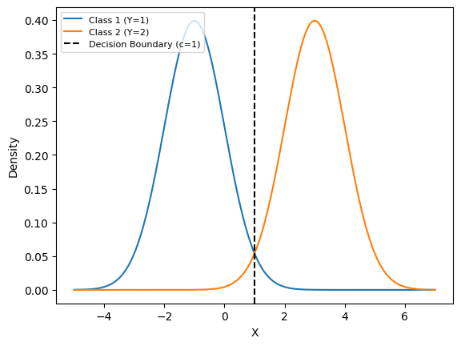

```python
import numpy as np
import matplotlib.pyplot as plt
from scipy.stats import norm

# generate a 1000-number sequence
x = np.linspace(-5,7,1000)
f1 = norm.pdf(x, loc=-1, scale=1)
f2 = norm.pdf(x, loc=3, scale=1)

plt.plot(x, f1, label='Class 1 (Y=1)')
plt.plot(x, f2, label='Class 2 (Y=2)')
plt.axvline(1, color='black', linestyle='--', label='Decision Boundary (c=1)')
plt.xlabel('X')
plt.ylabel('Density')
plt.legend(loc="upper left", fontsize=8)
plt.show()
```

**(b) Suppose the estimates were in fact obtained from 100 training points, among which 40 were from class 1 and 60 were from class 2. Further, suppose that you will estimate class priors from data. Assume that the class-specific sample means are still $\hat{\mu}_1=-1$ and $\hat{\mu}_2 = 3$, and the pooled variance estimate over the two classes is still $\hat{\sigma}^2=1.$. Now you could obtain an estimate of the Bayes decision boundary from this new LDA model; let us call the estimate $\tilde{c}$. Without actually doing this, would you be able to tell whether $\tilde{c}$ will be the same as, less than, or greater than $c$, or is there no way to tell? Explain your answer without calculating $\tilde{c}$. Note: It is okay to recheck your answer once you have actually calculated $\tilde{c}$ in part (c), but your explanation must not involve the numerical value.**

The $\tilde{c}$ will be different and will be smaller than $c$ because the prior $\pi_k$ is different, resulting in the decision boundary going to the left side.

**(c) Now calculate the new boundary value $\tilde{c}$ described in part (b)**

We can get new LDA function, denoted as $\delta_1^*(x)$ and $\delta_2^*(x)$. From the sample data, we can estimate that the class priors are: $$ \begin{align*} \pi_1^*=40/100=0.4 \\ \pi_2^*=60/100=0.6 \\ \end{align*} $$ Accordingly, we can get $$ \begin{align*} \delta_1^*(x) &=-x-\cfrac{1}{2}+\text{log}{0.4} \\ \delta_2^*(x) &=3x-\cfrac{9}{2}+\text{log}{0.6} \end{align*} $$ When $\delta_1^*(x)=\delta_2^*(x$, we can get new decision boundary $\tilde{c}=1+\cfrac{1}{4}\text{log}(\cfrac{2}{3})\approx0.8986$

**(d) Suppose in addition to the pooled covariance value $\hat{\sigma}^2$ I now tell you that the class-specific covariances were estimated as $\hat{\sigma}_1^2= 0.25$ and $\hat{\sigma}_2^2 = 1.5$. Based on this new information, would you recommend using LDA or QDA? Why?**

I will recommend using QDA, as the covariances are different this time

**(e) Derive the QDA rule if $\hat{\sigma}_1^2= 0.25$ and $\hat{\sigma}_2^2 = 1.5$ and $\hat{\mu}_1=-1$ and $\hat{\mu}_2 = 3$, assuming equal class priors. Calculate the numerical value for all points in the decision boundary of this rule.**

We still have $\pi_1=\pi_2=0.5$ Then we cen get the QDA function $$ \begin{align*} \delta_1(x) &= -\cfrac{x^2}{2\times0.25}+x\cdot\cfrac{-1}{0.25}-\cfrac{1}{2\times0.25}+\text{log}(\cfrac{1}{\sqrt{2\times0.25\pi}})+\text{log}{0.5}\\ \delta_2(x) &= -\cfrac{x^2}{2\times1.5}+x\cdot\cfrac{3}{1.5}-\cfrac{9}{2\times1.5}+\text{log}(\cfrac{1}{\sqrt{2\times1.5\pi}})+\text{log}{0.5}\\ \end{align*} $$ When $\delta_1(x)=\delta_2(x)$, there are the QDA decision boundaries $\hat{c}_1\approx0.292$ and $\hat{c}_2\approx-3.892$

#### Question 6

**The `Smarket` data set consists of percentage returns for the S&P 500 stock index over 1,250 days, from the beginning of 2001 until the end of 2005. For each date, we have recorded the percentage returns for each of the five previous trading days, `Lag1` through `Lag5`. We have also recorded the trading `Volume` (in billions of shares) for the previous trading day, and the return and direction (`Up` or `Down`) of the market on the date in question, `Today` and `Direction`. This data set can be downloaded from Canvas.**

**(a) Produce some numerical and graphical summaries of the `smarket` data. Do there appear to be any patterns?**

```
              Year         Lag1         Lag2         Lag3         Lag4  \
count  1250.000000  1250.000000  1250.000000  1250.000000  1250.000000
mean   2003.016000     0.003834     0.003919     0.001716     0.001636
std       1.409018     1.136299     1.136280     1.138703     1.138774
min    2001.000000    -4.922000    -4.922000    -4.922000    -4.922000
25%    2002.000000    -0.639500    -0.639500    -0.640000    -0.640000
50%    2003.000000     0.039000     0.039000     0.038500     0.038500
75%    2004.000000     0.596750     0.596750     0.596750     0.596750
max    2005.000000     5.733000     5.733000     5.733000     5.733000

             Lag5       Volume        Today
count  1250.00000  1250.000000  1250.000000
mean      0.00561     1.478305     0.003138
std       1.14755     0.360357     1.136334
min      -4.92200     0.356070    -4.922000
25%      -0.64000     1.257400    -0.639500
50%       0.03850     1.422950     0.038500
75%       0.59700     1.641675     0.596750
max       5.73300     3.152470     5.733000
```

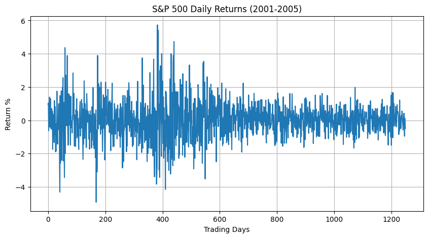

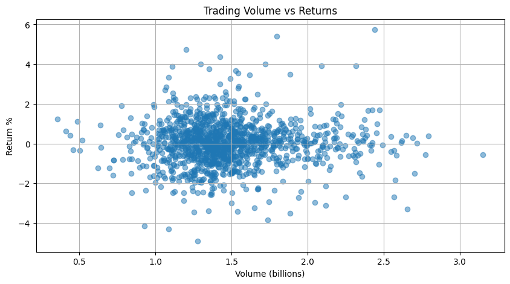

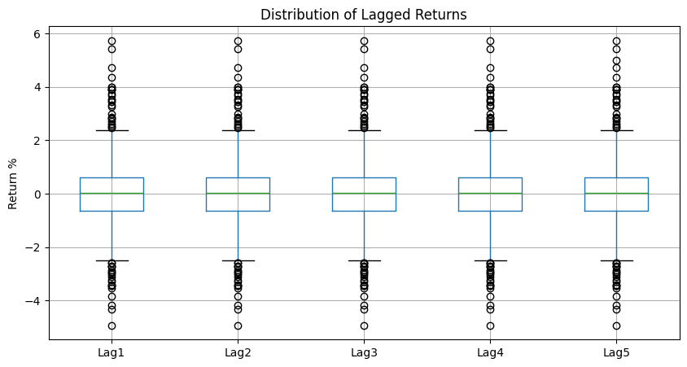

```python
import numpy as np
import pandas as pd
import matplotlib.pyplot as plt

smarket = pd.read_csv("smarket.csv", sep=",")
# show the numerical summaries except the first unnamed column
print(smarket.iloc[:,1:].describe())

# Time Series Plot of Daily Returns:
plt.figure(figsize=(10, 5))
plt.plot(smarket['Today'])
plt.title('S&P 500 Daily Returns (2001-2005)')
plt.ylabel('Return %')
plt.xlabel('Trading Days')
plt.grid(True)
plt.show()

# Volume vs Returns Scatter Plot:
plt.figure(figsize=(10, 5))
plt.scatter(smarket['Volume'], smarket['Today'], alpha=0.5)
plt.title('Trading Volume vs Returns')
plt.xlabel('Volume (billions)')
plt.ylabel('Return %')
plt.grid(True)
plt.show()

# Box Plot of Lagged Returns
lag_cols = ['Lag1', 'Lag2', 'Lag3', 'Lag4', 'Lag5']
plt.figure(figsize=(10, 5))
smarket[lag_cols].boxplot()
plt.title('Distribution of Lagged Returns')
plt.ylabel('Return %')
plt.grid(True)
plt.show()
```

**(b) Fit the LDA model using a training data period from 2001 to 2004, with `Direction` as the response and `Lag1` and `Lag2` as predictors. Use the model to estimate the Bayes optimal predictions on the held out test data (that is, the data from 2005). Compute the confusion matrix and the overall fraction of correct predictions for the test data.**

```python
train = smarket[smarket["Year"] != 2005][["Direction", "Lag1", "Lag2"]]
y_train = train["Direction"]
x_train = train[["Lag1", "Lag2"]]

test = smarket[smarket["Year"] == 2005][["Direction", "Lag1", "Lag2"]]
y_test = test["Direction"]
x_test = test[["Lag1", "Lag2"]]

# mu
mu_train = train.groupby("Direction")[["Lag1", "Lag2"]].mean()

# covariance matrix
sigma = np.cov(x_train.T)

# priors
pi = dict(y_train.value_counts() / len(y_train))

# LDA function
def lda_score(x, mu, sigma, pi):
    sigma_inv = np.linalg.inv(sigma)
    scores = {}

    for direction in ['Up', 'Down']:
        mu_k = mu.loc[direction].values
        prior = np.log(pi[direction])

        score = (x @ sigma_inv @ mu_k - 0.5 * mu_k.T @ sigma_inv @ mu_k + prior)
        scores[direction] = score

    return max(scores, key=scores.get)


y_pred = x_test.apply(lambda row: lda_score(row, mu_train, sigma, pi), axis=1)

# confussion matrix and
conf_matrix = confusion_matrix(y_test, y_pred)
accuracy = accuracy_score(y_test, y_pred)

print("\nConfusion Matrix:")
print(pd.DataFrame(conf_matrix,
                   index=['Actual Down', 'Actual Up'],
                   columns=['Predicted Down', 'Predicted Up']))
print(f"\nAccuracy: {accuracy:.4f}")
```

```
Confusion Matrix:
             Predicted Down  Predicted Up
Actual Down              35            76
Actual Up                35           106

Accuracy: 0.5595
```

**(c) Repeat (b) using QDA.**

```python
train = smarket[smarket["Year"] != 2005][["Direction", "Lag1", "Lag2"]]
y_train = train["Direction"]
x_train = train[["Lag1", "Lag2"]]

test = smarket[smarket["Year"] == 2005][["Direction", "Lag1", "Lag2"]]
y_test = test["Direction"]
x_test = test[["Lag1", "Lag2"]]

# mu
mu_train = train.groupby("Direction")[["Lag1", "Lag2"]].mean()

# priors
pi = dict(y_train.value_counts() / len(y_train))

# new covariance matrix
sigma_qda = {label: np.cov(x_train[y_train == label].T) for label in ['Up', 'Down']}

# qda function
def qda_score(x, mu, sigma, pi):
    scores = {}

    for direction in ['Up', 'Down']:
        mu_k = mu.loc[direction].values
        sigma_k = sigma[direction]
        sigma_k_inv = np.linalg.inv(sigma_k)
        det_sigma_k = np.linalg.det(sigma_k)

        # 计算 QDA 评分
        term1 = -0.5 * np.log(det_sigma_k)
        term2 = -0.5 * (x - mu_k).T @ sigma_k_inv @ (x - mu_k)
        term3 = np.log(pi[direction])

        scores[direction] = term1 + term2 + term3

    return max(scores, key=scores.get)

y_pred_qda = x_test.apply(lambda row: qda_score(row, mu_train, sigma_qda, pi), axis=1)

conf_matrix = confusion_matrix(y_test, y_pred_qda)
accuracy = accuracy_score(y_test, y_pred_qda)

print("\nConfusion Matrix:")
print(pd.DataFrame(conf_matrix,
                   index=['Actual Down', 'Actual Up'],
                   columns=['Predicted Down', 'Predicted Up']))
print(f"\nAccuracy: {accuracy:.4f}")
```

```
Confusion Matrix:
             Predicted Down  Predicted Up
Actual Down              30            81
Actual Up                20           121

Accuracy: 0.5992
```

#### Question 7

**In this problem, you will develop a model to predict whether a given car will be classified as having high or low gas mileage based on the `Auto` data set. Download this data set from Canvas and load it as a data frame.**

**(a) Create a binary variable, `mpg01`, that is equal to 1 if the value of `mpg` for that car is above 25, and 0 otherwise. Add this variable as a new column to your data frame.**

```python
auto = pd.read_csv("auto.csv", sep=",")
auto["mpg01"] =  np.where(auto["mpg"] > 25, 1, 0)
auto = auto.iloc[:, 1:]
auto.head()
```

|  | mpg | cylinders | displacement | horsepower | weight | acceleration | year | origin | name | mpg01 |
| --- | --- | --- | --- | --- | --- | --- | --- | --- | --- | --- |
| 0 | 18.0 | 8 | 307.0 | 130 | 3504 | 12.0 | 70 | 1 | chevrolet chevelle malibu | 0 |
| 1 | 15.0 | 8 | 350.0 | 165 | 3693 | 11.5 | 70 | 1 | buick skylark 320 | 0 |
| 2 | 18.0 | 8 | 318.0 | 150 | 3436 | 11.0 | 70 | 1 | plymouth satellite | 0 |
| 3 | 16.0 | 8 | 304.0 | 150 | 3433 | 12.0 | 70 | 1 | amc rebel sst | 0 |
| 4 | 17.0 | 8 | 302.0 | 140 | 3449 | 10.5 | 70 | 1 | ford torino | 0 |

**(b) Make some exploratory plots to investigate the association between `mpg01` and other variables. Describe your findings. Besides `mpg` itself, which four quantitative features do you think are most likely to be useful in predicting mpg01? There is no right answer here, but you should defend your argument with plots (e.g. side-by-side boxplots).**

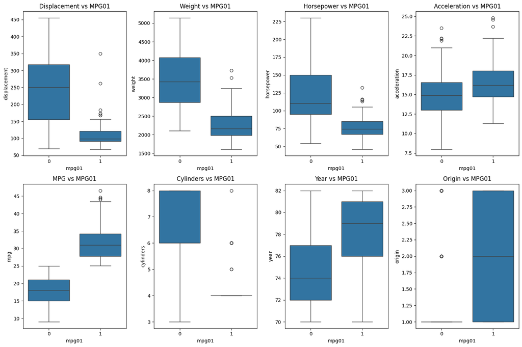

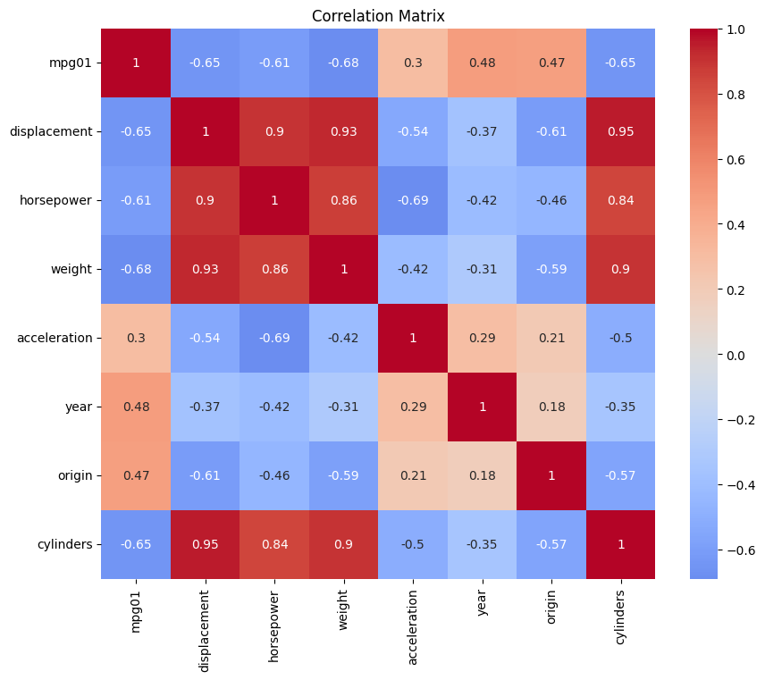

```python
import pandas as pd
import numpy as np
import matplotlib.pyplot as plt
import seaborn as sns

plt.figure(figsize=(15, 10))

# 1. displacement vs mpg01
plt.subplot(2, 4, 1)
sns.boxplot(x='mpg01', y='displacement', data=auto)
plt.title('Displacement vs MPG01')

# 2. weight vs mpg01
plt.subplot(2, 4, 2)
sns.boxplot(x='mpg01', y='weight', data=auto)
plt.title('Weight vs MPG01')

# 3. horsepower vs mpg01
plt.subplot(2, 4, 3)
sns.boxplot(x='mpg01', y='horsepower', data=auto)
plt.title('Horsepower vs MPG01')

# 4. acceleration vs mpg01
plt.subplot(2, 4, 4)
sns.boxplot(x='mpg01', y='acceleration', data=auto)
plt.title('Acceleration vs MPG01')

plt.subplot(2, 4, 5)
sns.boxplot(x='mpg01', y='mpg', data=auto)
plt.title('MPG vs MPG01')

plt.subplot(2, 4, 6)
sns.boxplot(x='mpg01', y='cylinders', data=auto)
plt.title('Cylinders vs MPG01')

plt.subplot(2, 4, 7)
sns.boxplot(x='mpg01', y='year', data=auto)
plt.title('Year vs MPG01')

plt.subplot(2, 4, 8)
sns.boxplot(x='mpg01', y='origin', data=auto)
plt.title('Origin vs MPG01')

plt.tight_layout()
plt.show()

numeric_cols = ['mpg01', 'displacement', 'horsepower', 'weight', 'acceleration', 'year', 'origin', 'cylinders']
correlation_matrix = auto[numeric_cols].corr()

plt.figure(figsize=(10, 8))
sns.heatmap(correlation_matrix, annot=True, cmap='coolwarm', center=0)
plt.title('Correlation Matrix')
plt.show()
```

According to the side by side boxplot, I think `displacement`, `horsepower`, `weight` and `year` are most likely useful in predicting `mpg01`

**(c) Split the data into a training set and a test set. Use `sklearn.model_selection.train_test_split` to split the data. Be sure to supply the following arguments: `random_state` should be 123, `train_size` should be 0.8, and `stratify` should be set to the values of your new binary feature mpg01. Report the number of samples in the trainset where `mpg01` is 1.**

```python
from sklearn.model_selection import train_test_split
X = auto[["displacement","horsepower","weight","year"]].values
y = auto["mpg01"].values
X_train, X_test, y_train, y_test = train_test_split(X, y, random_state = 123,
                                                   train_size = 0.8,
                                                   stratify = y)
n_sample = np.sum(y_train == 1)
print(f"The proportion of the trainset where mpg01 is 1: {n_sample}")
```

```
The proportion of the trainset where mpg01 is 1: 125
```

**(d) Fit an LDA model on the training data, using the four quantitative variables that seem most associated with `mpg01` based on (b). Use the model to estimate the Bayes optimal predictions for the responses in the training and test data. Report the misclassification rate for your predictions on training and test data. Choose two of the four variables based on (b), and make a scatterplot of the training data points. Use different colors to indicate the true values of mpg01 and different plotting symbols (e.g., + and o) to indicate predicted values.**

```
Training Misclassification Rate: 0.09904153354632583
Test Misclassification Rate: 0.1392405063291139
```

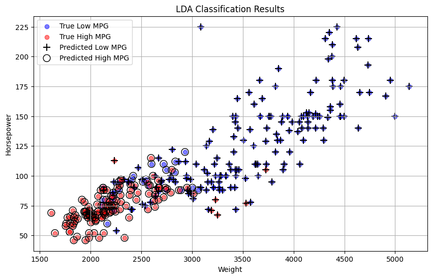

```
Training Confusion Matrix:
[[164  24]
 [  7 118]]

Test Confusion Matrix:
[[39  9]
 [ 2 29]]
```

```python
from sklearn.discriminant_analysis import LinearDiscriminantAnalysis as LDA
lda = LDA()
lda.fit(X_train, y_train)

y_train_pred_l = lda.predict(X_train)
y_test_pred_l = lda.predict(X_test)

train_misclass_l = 1 - accuracy_score(y_train, y_train_pred_l)
test_misclass_l = 1 - accuracy_score(y_test, y_test_pred_l)
print("Training Misclassification Rate:", train_misclass_l)
print("Test Misclassification Rate:", test_misclass_l)

plt.figure(figsize=(10, 6))

# plot original data using different color
plt.scatter(X_train[y_train==0, 2], X_train[y_train==0, 1],
           c='blue', label='True Low MPG', alpha=0.5)
plt.scatter(X_train[y_train==1, 2], X_train[y_train==1, 1],
           c='red', label='True High MPG', alpha=0.5)

# plot predicted data using different symbol
plt.scatter(X_train[y_train_pred_l==0, 2], X_train[y_train_pred_l==0, 1],
           marker='+', c='black', s=100, label='Predicted Low MPG')
plt.scatter(X_train[y_train_pred_l==1, 2], X_train[y_train_pred_l==1, 1],
           marker='o', facecolors='none', edgecolors='black', s=100,
           label='Predicted High MPG')

plt.xlabel('Weight')
plt.ylabel('Horsepower')
plt.title('LDA Classification Results')
plt.legend()
plt.grid(True)
plt.show()

print("\nTraining Confusion Matrix:")
print(confusion_matrix(y_train, y_train_pred_l))
print("\nTest Confusion Matrix:")
print(confusion_matrix(y_test, y_test_pred_l))
```

**(e) Repeat exercise 7d, but using QDA this time. Fit a QDA model on training data, use it to estimate Bayes optimal predictions, calculate training and test misclassification rates, and make a plot analogous to the one in problem 7d, using the same two variables.**

```
Training Misclassification Rate: 0.1309904153354633
Test Misclassification Rate: 0.189873417721519
```

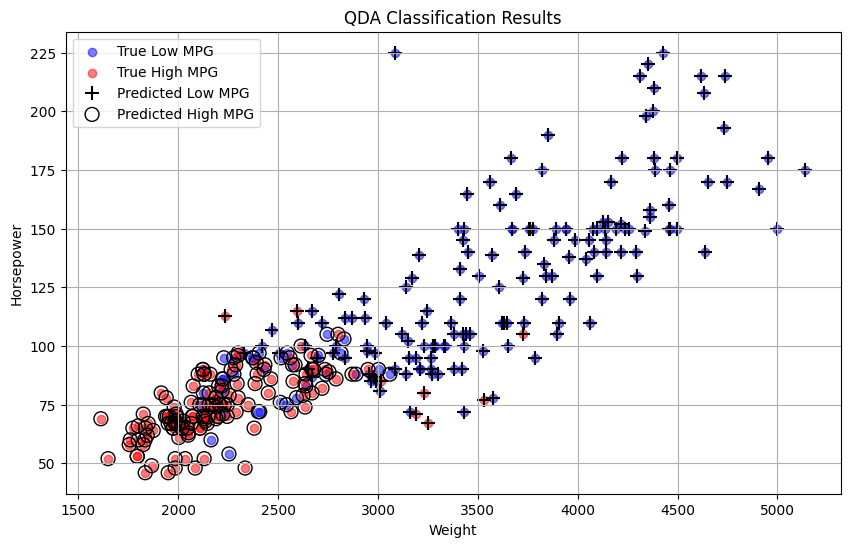

```
Training Confusion Matrix:
[[155  33]
 [  8 117]]

Test Confusion Matrix:
[[37 11]
 [ 4 27]]
```

```python
from sklearn.discriminant_analysis import QuadraticDiscriminantAnalysis as QDA
qda = QDA()

qda.fit(X_train, y_train)

y_train_pred_q = qda.predict(X_train)
y_test_pred_q = qda.predict(X_test)

train_misclass_q = 1 - accuracy_score(y_train, y_train_pred_q)
test_misclass_q = 1 - accuracy_score(y_test, y_test_pred_q)
print("Training Misclassification Rate:", train_misclass_q)
print("Test Misclassification Rate:", test_misclass_q)


plt.figure(figsize=(10, 6))

# plot original data using different color
plt.scatter(X_train[y_train==0, 2], X_train[y_train==0, 1],
           c='blue', label='True Low MPG', alpha=0.5)
plt.scatter(X_train[y_train==1, 2], X_train[y_train==1, 1],
           c='red', label='True High MPG', alpha=0.5)

# plot predicted data using different symbol
plt.scatter(X_train[y_train_pred_q==0, 2], X_train[y_train_pred_q==0, 1],
           marker='+', c='black', s=100, label='Predicted Low MPG')
plt.scatter(X_train[y_train_pred_q==1, 2], X_train[y_train_pred_q==1, 1],
           marker='o', facecolors='none', edgecolors='black', s=100,
           label='Predicted High MPG')

plt.xlabel('Weight')
plt.ylabel('Horsepower')
plt.title('QDA Classification Results')
plt.legend()
plt.grid(True)
plt.show()

print("\nTraining Confusion Matrix:")
print(confusion_matrix(y_train, y_train_pred_q))
print("\nTest Confusion Matrix:")
print(confusion_matrix(y_test, y_test_pred_q))
```

**(f) Compare and contrast the performance of LDA and QDA. What do your results suggest about the class-specific covariances?**

I suggest that LDA is better because both test misclassification and training misclassification are lower when using LDA.

**(g) Repeat exercise 7d, but using logistic regression this time. Fit a logistic regression model on training data, use it to estimate Bayes optimal predictions, calculate training and test misclassification rates, and make a plot analogous to the one in problem 7d, using the same two variables.**

```
Training Misclassification Rate: 0.09265175718849838
Test Misclassification Rate: 0.08860759493670889
```

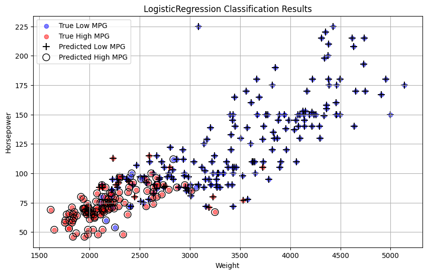

```
Training Confusion Matrix:
[[175  13]
 [ 16 109]]

Test Confusion Matrix:
[[45  3]
 [ 4 27]]
```

```python
from sklearn.linear_model import LogisticRegression
lr = LogisticRegression()
lr.fit(X_train, y_train)

y_train_pred_lr = lr.predict(X_train)
y_test_pred_lr = lr.predict(X_test)

train_misclass_lr = 1 - accuracy_score(y_train, y_train_pred_lr)
test_misclass_lr = 1 - accuracy_score(y_test, y_test_pred_lr)
print("Training Misclassification Rate:", train_misclass_lr)
print("Test Misclassification Rate:", test_misclass_lr)


plt.figure(figsize=(10, 6))

# plot original data using different color
plt.scatter(X_train[y_train==0, 2], X_train[y_train==0, 1],
           c='blue', label='True Low MPG', alpha=0.5)
plt.scatter(X_train[y_train==1, 2], X_train[y_train==1, 1],
           c='red', label='True High MPG', alpha=0.5)

# plot predicted data using different symbol
plt.scatter(X_train[y_train_pred_lr==0, 2], X_train[y_train_pred_lr==0, 1],
           marker='+', c='black', s=100, label='Predicted Low MPG')
plt.scatter(X_train[y_train_pred_lr==1, 2], X_train[y_train_pred_lr==1, 1],
           marker='o', facecolors='none', edgecolors='black', s=100,
           label='Predicted High MPG')

plt.xlabel('Weight')
plt.ylabel('Horsepower')
plt.title('LogisticRegression Classification Results')
plt.legend()
plt.grid(True)
plt.show()

print("\nTraining Confusion Matrix:")
print(confusion_matrix(y_train, y_train_pred_lr))
print("\nTest Confusion Matrix:")
print(confusion_matrix(y_test, y_test_pred_lr))
```

**(h) Using your fitted logistic regression model, estimate the probability of a car having mpg above 25 if its values for the four predictors are all at the corresponding median values in the training dataset.**

```python
X_new = np.median(X_train, axis=0).reshape(1,4)
y_new = 1
y_new_prob_lr = lr.predict_proba(X_new)
print(f"The probability of new data having mpg above 25: {y_new_prob_lr[0][1]}")
```

```
The probability of new data having mpg above 25: 0.2054037082859377
```

**(i)Now consider applying KNN classification to this problem. Make plots of the training classification error and the test classification error as a function of the number of neighbors $K$ (or $1/K$; if you use $1/K$, make sure the x-axis is on the log scale). Which $K$ gives the best performance on the training data? On the test data? Which $K$ would you use?**

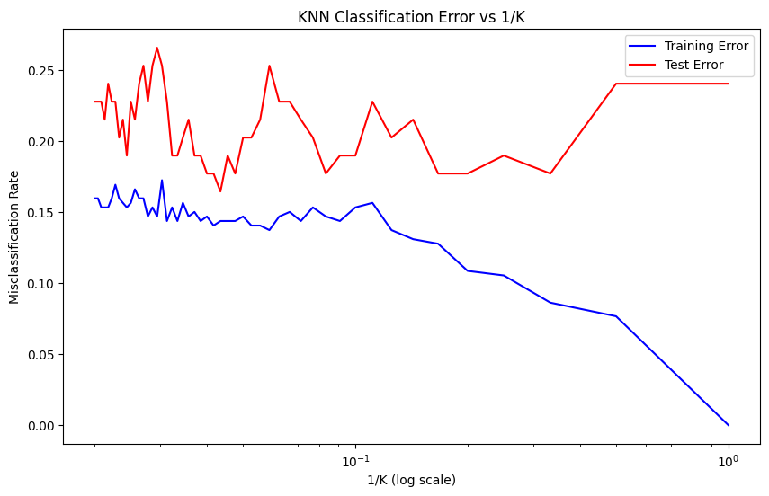

```
Best K on test data: 23
Best K on training data: 1
```

```python
from sklearn.neighbors import KNeighborsClassifier

K_values = range(1, 51)
train_errors = []
test_errors = []

for k in K_values:
    knn = KNeighborsClassifier(n_neighbors=k)
    knn.fit(X_train, y_train)
    # Training error
    train_pred = knn.predict(X_train)
    train_error = 1 - accuracy_score(y_train, train_pred)
    train_errors.append(train_error)
    # Test error
    test_pred = knn.predict(X_test)
    test_error = 1 - accuracy_score(y_test, test_pred)
    test_errors.append(test_error)

# Plot errors vs 1/K (log scale)
plt.figure(figsize=(10, 6))
plt.plot(1 / np.array(K_values), train_errors, 'b-', label='Training Error')
plt.plot(1 / np.array(K_values), test_errors, 'r-', label='Test Error')
plt.xscale('log')
plt.xlabel('1/K (log scale)')
plt.ylabel('Misclassification Rate')
plt.legend()
plt.title('KNN Classification Error vs 1/K')
plt.show()

# Find best K for test data
best_test_k = K_values[np.argmin(test_errors)]
best_test_error = np.min(test_errors)
print(f"Best K on test data: {best_test_k}")

# Find best K for training data
best_train_k = K_values[np.argmin(train_errors)]
best_train_error = K_values[np.argmin(train_errors)]
print(f"Best K on training data: {best_train_k}")
```

I will use the best $K$ for test data, 23

**(j) Repeat exercise 7d, using KNN this time, using the number of neighbors chosen in 7i. Fit a KNN classification model on training data, use it to estimate Bayes optimal predictions, calculate training and test misclassification rates, and make a plot analogous to the one in problem 7d, using the same two variables**

```
Training Misclassification Rate: 0.1437699680511182
Test Misclassification Rate: 0.16455696202531644
```

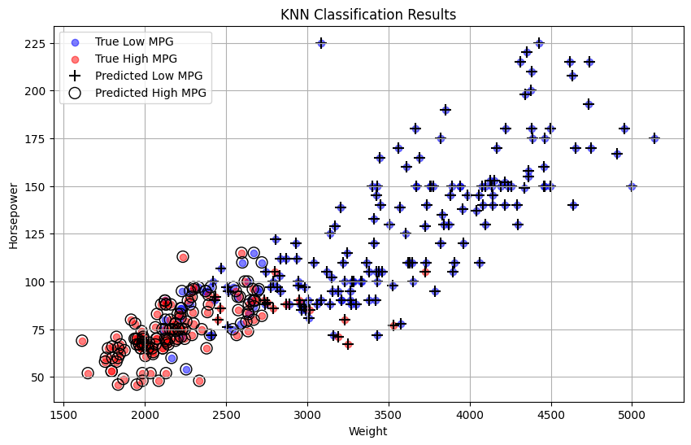

```
Training Confusion Matrix:
[[158  30]
 [ 15 110]]

Test Confusion Matrix:
[[41  7]
 [ 6 25]]
```

```python
knn = KNeighborsClassifier(n_neighbors = best_test_k)
knn.fit(X_train, y_train)

y_train_pred_k = knn.predict(X_train)
y_test_pred_k = knn.predict(X_test)

train_misclass_k = 1 - accuracy_score(y_train, y_train_pred_k)
test_misclass_k = 1 - accuracy_score(y_test, y_test_pred_k)

print("Training Misclassification Rate:", train_misclass_k)
print("Test Misclassification Rate:", test_misclass_k)

plt.figure(figsize=(10, 6))

# plot original data using different color
plt.scatter(X_train[y_train==0, 2], X_train[y_train==0, 1],
           c='blue', label='True Low MPG', alpha=0.5)
plt.scatter(X_train[y_train==1, 2], X_train[y_train==1, 1],
           c='red', label='True High MPG', alpha=0.5)

# plot predicted data using different symbol
plt.scatter(X_train[y_train_pred_k==0, 2], X_train[y_train_pred_k==0, 1],
           marker='+', c='black', s=100, label='Predicted Low MPG')
plt.scatter(X_train[y_train_pred_k==1, 2], X_train[y_train_pred_k==1, 1],
           marker='o', facecolors='none', edgecolors='black', s=100,
           label='Predicted High MPG')

plt.xlabel('Weight')
plt.ylabel('Horsepower')
plt.title('KNN Classification Results')
plt.legend()
plt.grid(True)
plt.show()

print("\nTraining Confusion Matrix:")
print(confusion_matrix(y_train, y_train_pred_k))
print("\nTest Confusion Matrix:")
print(confusion_matrix(y_test, y_test_pred_k))
```

**(k) Using your fitted KNN model, estimate the probability of a car having mpg above 25 if its values for the four predictors are all at the corresponding median values in the training dataset.**

```python
y_new_proba_k = knn.predict_proba(X_new)
print(f"The probability of new data having mpg above 25: {y_new_proba_k[0][1]}")
```

[output not shown]

**(l) Compare and contrast the performance of LDA, QDA, logistic regression, and KNN on this dataset. What do your results suggest about the distribution of the data? About the nature of the boundary between classes? There is no one right answer here, but we expect you to defend your conclusions using your findings from earlier in this problem.**

I will suggest using logistic regression to do the classifiction because logistic regression get both the lowest training misclassification and test misclassification. This indicates that the boundary between classes is linear.